# Midterm Exam for P8116, Advanced Computing

Minghe Wang, mw3845:

**Honor Code**

I, the undersigned, affirm that I will complete this exam solely using my own knowledge and the materials provided within the coursework. I agree not to use any external resources such as Google, websites other than those provided in the coursework, or any artificial intelligence tools. I understand that any violation of this policy constitutes a breach of academic integrity and may result in disciplinary action, including a failing grade for this exam.

By beginning this exam, I acknowledge and agree to abide by the above honor code.

**Signature: Minghe Wang**

**Date: 2025-03-10**

**Problem 1: Random Number Generation [25 points]**

1. Inverse CDF (Quantile) Method: consider the probability density function defined as:
   $$f(x)= 2x,
   x\in[0,1]$$
   1. Derive the cumulative distribution function (CDF) for $f(x)$ and then obtain the inverse CDF.
   2. Use the inverse CDF method to generate a sample of $N=500$ values from this distribution.
   3. Plot a histogram of the generated samples and overlay the theoretical density to confirm your results.
   4. Discuss the conditions a distribution must satisfy for the inverse CDF method to be applicable.
2. Acceptance–Rejection Method
   1. Outline the steps of the acceptance–rejection algorithm.
   2. Use acceptance–rejection to generate samples from a truncated Normal distribution, $N(0,1)$ conditioned on $x>0$. Use a simpler proposal distribution (e.g., exponential) that covers $x>0$.
   3. Discuss the efficiency (the acceptance rate) of your approach.

```r
# 1.
# a CDF F(x) = x^2
# b
generate_x <- function(n){
  u <- runif(n)
  x <- sqrt(u)
  return(x)
}
n <- 500
set.seed(123)

randX <- generate_x(n)
# c
hist(randX, probability = TRUE, main = paste('sample size =', n), xlab = 'x')
curve(2*x, from=0, to=max(randX), add = TRUE, col = 'red')


# 2.
# a
X_rej = NULL
accepted <- 0
M=1
n2=10000
lambda=1
set.seed(123)

for (i in 1:n2) {
  Y <- rexp(1, lambda)
  f_y <- ifelse(Y > 0, (2 / sqrt(2*pi)) * exp(-Y^2 / 2), 0)
  g_y <- dexp(Y, rate = lambda)

  if (runif(1) < f_y / (M * g_y)) {
    X_rej <- c(X_rej, Y)
    accepted <- accepted + 1
  }
}
acceptance_rate <- accepted / n2

cat("Acceptance rate:", acceptance_rate, "\n")
```

[output not shown]

**Ans:**

- 1.a F(x) = $x^2, x \in [0, 1]$
- 1.d The distribution need to have a closed form inverse PDF
- 2.c The acceptance rate is 0.8859. We simulate 10^{4} times to obtain a valid result, and it shows that the acceptance probability is relative high.

**Problem 2: Monte Carlo Integration [25 points]**

1. Implement a Monte Carlo approximation for

$$\int_{-1}^1 \ln(1+x^2) dx$$

2. Report the mean of your estimates and approximate 95% confidence intervals using the sample standard deviation.
3. Compare your Monte Carlo estimate to a numerical integration routine and discuss the difference.
4. Propose a control variate function for the integral, and explain why you think it might be effective.
5. Implement the Monte Carlo estimator with and without the control variate. Compare the variances of both methods and comment on any observed improvements.

```r
# a
set.seed(123)
n2 <- 10000
a <- -1
b <- 1

x_samples <- runif(n2, min = a, max = b)
f_values <- log(1 + x_samples^2)
I_est <- (b - a) * mean(f_values)

s <- sd(f_values)
SE <- (b - a) * s / sqrt(n)

CI_lower <- I_est - 1.96 * SE
CI_upper <- I_est + 1.96 * SE

# c
numerical_result <- integrate(function(x) log(1+x^2), lower = -1, upper = 1)

# e
u <- runif(n2, min = a, max = b)
# Evaluate f(x) and h(x)
f <- function(x){
  log(1 + x^2)
}
m <- function(x){
  return(x^2)
}
f_vals <- f(u)
m_vals <- m(u)
interval_length <- (b - a)
I_hat <- interval_length * f_vals

# Estimate the optimal beta
#beta_opt <- cov(f_vals, m_vals) / var(m_vals)
beta_opt <- lm(f_vals ~ m_vals)$coef[2]
# Control variate estimator:
I_hat_cv <- interval_length * (f_vals - beta_opt * (m_vals - 1/3) )

mean_standard2 <- mean(I_hat)
var_standard2 <- var(I_hat)

mean_cv2 <- mean(I_hat_cv)
var_cv2 <- var(I_hat_cv)

cat("Standard Monte Carlo estimate: Mean =", mean_standard2, ", Variance =", var_standard2, "\n")
```

```
Standard Monte Carlo estimate: Mean = 0.5270095 , Variance = 0.1838274
```

```r
cat("Control Variate estimate:      Mean =", mean_cv2, ", Variance =", var_cv2, "\n")
```

```
Control Variate estimate:      Mean = 0.5282707 , Variance = 0.001477322
```

**Ans:**

**Problem 3: Newton’s Method [25 points]**

Consider a two parameter function
$$f(a,b)=-a^2-b^2 +4a + 6b$$

1. Derive the gradient vector $\nabla f(a,b)$ and the Hessian matrix $\nabla^2 f(a,b)$
2. Find analytical solution that maximize $f(a,b)$, i.e.,
   $$(a^*, b^*) = \arg \max f(a,b)$$
3. Implement Newton’s method for maximization of $f(a,b)$
4. Plot the value of $f(a,b)$ versus the iteration number to illustrate the convergence behavior, and briefly discuss the convergence properties observed in your implementation.

```r
f <- function(a, b) {
  -a^2 - b^2 + 4*a + 6*b
}
grad <- function(a, b){
  c(-2*a + 4, -2*b + 6)
}
hess <- matrix(c(-2, 0,
              0, -2), nrow = 2, byrow = TRUE)

newtonRalphson <- function(a0, b0, grad, hess, tol=1e-10, max_iter=10){
  i <- 0
  a <- a0
  b <- b0
  hess_inv <- solve(hess)
  g_val <- grad(a, b)
  f_vals <- c(f(a,b))
  res <- c(a, b, g_val, f_vals, i)
  prev_a <- -Inf
  prev_b <- -Inf
  while(i < max_iter){# && (a-prev_a > tol) && (b-prev_b > tol)){#sqrt(sum(g_val^2)) > tol){
    i <- i + 1
    curr <- hess_inv %*% g_val
    prev_a <- a
    prev_b <- b
    a <- a - curr[1]
    b <- b - curr[2]
    g_val <- grad(a, b)
    f_vals <- f(a, b)
    res <- rbind(res, c(a, b, g_val, f_vals, i))
  }
  return(res)
}
set.seed(123)
result <- newtonRalphson(a0 = 0, b0 = 0, grad, hess)
print(result)
```

```
    [,1] [,2] [,3] [,4] [,5] [,6]
res    0    0    4    6    0    0
       2    3    0    0   13    1
       2    3    0    0   13    2
       2    3    0    0   13    3
       2    3    0    0   13    4
       2    3    0    0   13    5
       2    3    0    0   13    6
       2    3    0    0   13    7
       2    3    0    0   13    8
       2    3    0    0   13    9
       2    3    0    0   13   10
```

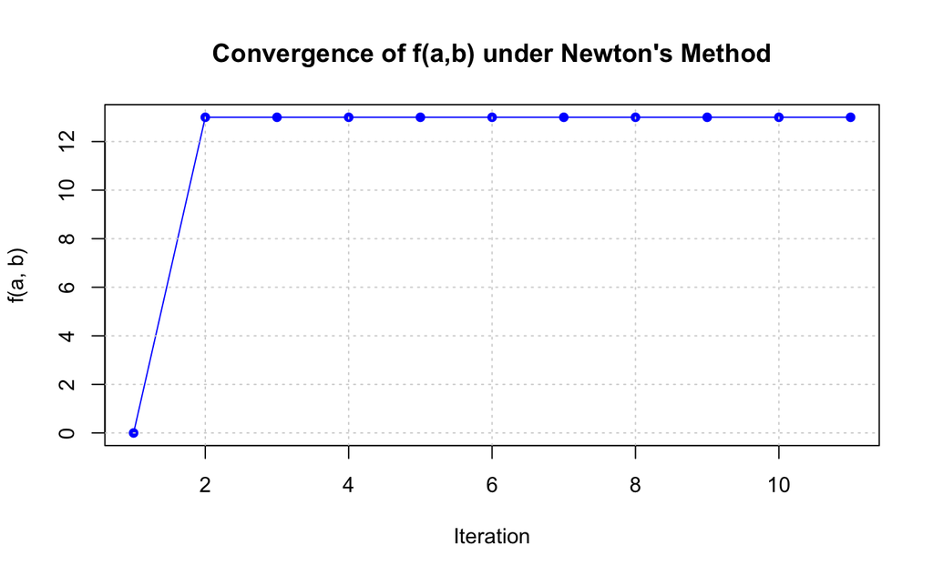

```r
plot(result[,5], type = "o", pch = 16, col = "blue",
     xlab = "Iteration", ylab = "f(a, b)",
     main = "Convergence of f(a,b) under Newton's Method")
grid()
```

**Ans:**

- 1. $\nabla f(a,b) = (^{-2a+4}_{-2b+6})$ , $\nabla^2 f(a,b) = \left(\begin{array}{cc} -2 & 0\\ 0 & -2\end{array}\right)$
- 2. f(2, 3) = 13
- 4. The plot above shows a very rapid (quadratic) convergence toward the optimum(at first updating).

**Problem 4: EM Algorithm [25 points]**

Suppose you have Bernoulli mixture data, $x_1, x_2,...,x_n$, that come from a mixture of two Bernoulli distributions with unknown parameters:
$$X\sim \pi B(1,p_1) + (1-\pi) B(1, p_2),$$
where $B(1, p)$ represents Bernoulli distribution with success probability $p$.

1. write down Write down the likelihood (and log-likelihood) for the dataset ${x_i} under the above mixture model.
2. write out E-step and M-step with formulas for updating $\pi, p_1, p_2$.
3. Implement your EM algorithm with a synthetic data of sample size $n=100$, with true parameter $\pi=0.4, p_1=0.7, p_2=0.2$. Provide the final estimates and plot or tabulate the change in the log-likelihood over iterations.
4. What difficulties can arise if $p_1$ or $p_2$ are initially very close to 0 or 1? Do you observe convergence or numerical issues? What would you suggest to robustiy EM algorithm?

```r
delta_bernoulli <- function(X, pars){
  num <- pars$p * (pars$p2^X) * ((1 - pars$p2)^(1 - X))
  denom <- (1 - pars$p) * (pars$p1^X) * ((1 - pars$p1)^(1 - X)) + num
  return(num / denom)
}

mles_bernoulli <- function(Z, X) {
  n <- length(X)
  phat <- sum(Z)/n
  p1hat <- sum((1 - Z) * X) / sum(1 - Z)
  p2hat <- sum(Z * X) / sum(Z)
  return(list(p = phat, p1 = p1hat, p2 = p2hat))
}

EM_bernoulli <- function(X, start, nreps = 10) {
  i <- 0
  Z <- delta_bernoulli(X, start)
  newpars <- start
  res <- rbind(c(0, newpars$p, newpars$p1, newpars$p2))

  while (i < nreps) {
    i <- i + 1
    # M-step: update parameters given the responsibilities
    newpars <- mles_bernoulli(Z, X)
    # E-step: update responsibilities using the new parameters
    Z <- delta_bernoulli(X, newpars)
    res <- rbind(res, c(i, newpars$p, newpars$p1, newpars$p2))
  }

  colnames(res) <- c("iter", "p", "p1", "p2")
  return(res)
}


n <- 100
pi_true <- 0.4
p1_true <- 0.7
p2_true <- 0.2
set.seed(123)
# Generate latent indicators
z_true <- rbinom(n, size = 1, prob = pi_true)

# Get data
x <- ifelse(z_true == 1, rbinom(n, size = 1, prob = p2_true),
            rbinom(n, size = 1, prob = p1_true))

# Initial guesses
start <- list(p = 0.2, p1 = 0.3, p2 = 0.1)

# Run the EM algorithm
em_results <- EM_bernoulli(x, start, nreps = 10)
print(em_results)
```

```
      iter         p        p1        p2
 [1,]    0 0.2000000 0.3000000 0.1000000
 [2,]    1 0.1634096 0.5296223 0.2259542
 [3,]    2 0.1634096 0.5296223 0.2259542
 [4,]    3 0.1634096 0.5296223 0.2259542
 [5,]    4 0.1634096 0.5296223 0.2259542
 [6,]    5 0.1634096 0.5296223 0.2259542
 [7,]    6 0.1634096 0.5296223 0.2259542
 [8,]    7 0.1634096 0.5296223 0.2259542
 [9,]    8 0.1634096 0.5296223 0.2259542
[10,]    9 0.1634096 0.5296223 0.2259542
[11,]   10 0.1634096 0.5296223 0.2259542
```

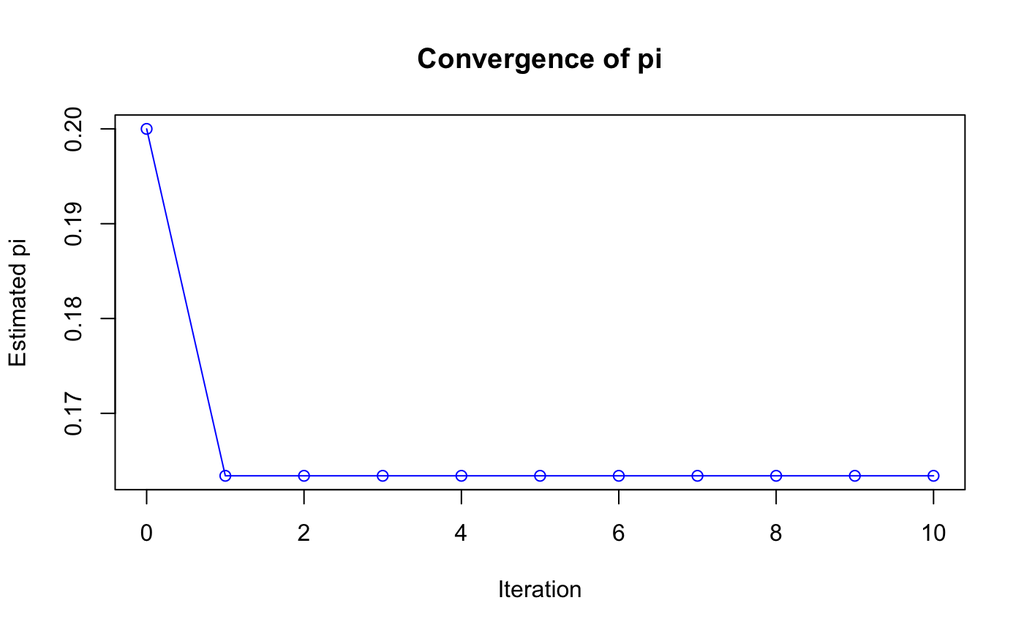

```r
# Plot the estimated mixing probability over iterations
plot(em_results[,"iter"], em_results[,"p"], type="o", col="blue",
     xlab="Iteration", ylab="Estimated pi", main="Convergence of pi")
abline(h = pi_true, col="red", lty=2)
```

**Ans:**

likelihood: $L(x) = \prod_{i=1}^{n}(1-\pi)p_2^{x_i}(1-p_2)^{x_i} + \pi p_1^{x_i}(1-p_1)^{x_i}$

log-likelihood: $l(x) = \sum_{i=1}^{n} ln((1-\pi)p_2^{x_i}(1-p_2)^{x_i} + \pi p_1^{x_i}(1-p_1)^{x_i})$

- 2. E-step: $Z_i = \frac{\pi p_1^{x_i}(1-p_1)^{x_i}}{(1-\pi)p_2^{x_i}(1-p_2)^{x_i} + \pi p_1^{x_i}(1-p_1)^{x_i}}$

M-step: $\pi = \frac{1}{n}\sum^{n}_{i=1} Z_i$, $p_1 = \frac{\sum^{n}_{i=1}Z_i x_i}{\sum^{n}_{i=1}Z_i}$, $p_2 = \frac{\sum^{n}_{i=1}(1-Z_i) x_i}{\sum^{n}_{i=1}(1-Z_i)}$

- 3. According to the plot, the estimation is indeed converging. However, estimated parameters are not as accurate
- 4. Extreme initial values for p1 or p2(close to 0 or 1) may cause numerical instability and degenerate responsibilities. To robustify the EM algorithm, we can use multiple initializations, add regularization(pseudo–counts), or work with a transformed parameter(log–odds).